# MapOSR

Inter-Rater-Agreement

Jürgen Schneider

2022-04-14

# Setup

Libraries and R version.

```r
knitr::opts_chunk$set(echo = TRUE,
                      warning=FALSE,
                      message=FALSE,
                      comment=FALSE)
library(tidyverse)
library(irr)
library(kableExtra)
installed.packages()[names(sessionInfo()$otherPkgs), "Version"]
```

```
FALSE kableExtra        irr    lpSolve    forcats    stringr      dplyr      purrr
FALSE    "1.3.4"   "0.84.1"   "5.6.15"    "0.5.1"    "1.4.0"    "1.0.8"    "0.3.4"
FALSE      readr      tidyr     tibble    ggplot2  tidyverse
FALSE    "2.1.2"    "1.2.0"    "3.1.6"    "3.3.5"    "1.3.1"
```

```r
R.Version()
```

```
FALSE $platform
FALSE [1] "x86_64-w64-mingw32"
FALSE
FALSE $arch
FALSE [1] "x86_64"
FALSE
FALSE $os
FALSE [1] "mingw32"
FALSE
FALSE $system
FALSE [1] "x86_64, mingw32"
FALSE
FALSE $status
FALSE [1] ""
FALSE
FALSE $major
FALSE [1] "4"
FALSE
FALSE $minor
FALSE [1] "0.2"
FALSE
FALSE $year
FALSE [1] "2020"
FALSE
FALSE $month
FALSE [1] "06"
FALSE
FALSE $day
FALSE [1] "22"
FALSE
FALSE $`svn rev`
FALSE [1] "78730"
FALSE
FALSE $language
FALSE [1] "R"
FALSE
FALSE $version.string
FALSE [1] "R version 4.0.2 (2020-06-22)"
FALSE
FALSE $nickname
FALSE [1] "Taking Off Again"
```

# Import & Wrangling

Data import. You can get the underlying data for this document on github (github.com/JanaLasser/mapping-open-science-research) or download it directly from this document.

```r
# IMPORT ########################################################################
rel <- rio::import(here::here("02_data_tidy/reliability_clean.csv"))
```

There were 5 categories to be coded:

- action
- method
- discipline
- group
- geo

Since the categories had multiple-choice answer labels, these labels were dichotomized (dummy coded). For each **label** on these categories, there is now a variable (e.g. group_librarian, group_policy, …) on which “1” (applies to the publication) or “0” (does *not* apply to the publication) was coded.

Variables beginning with `c1_` refer to the first coder, variables beginning with `c2_` refer to the second coder.

Accordingly, this type of table:

```r
rel[1:5,] %>%
  kbl() %>%
  kable_styling()
```

| ID | c1_action | c1_method | c1_discipline | c1_group | c1_geo | c2_action | c2_method | c2_discipline | c2_group | c2_geo |
| --- | --- | --- | --- | --- | --- | --- | --- | --- | --- | --- |
| 5 | a=openaccess | m=biblio; m=documentreview | d=nonspecific | t=publisher | geo=ESP | a=openpolicies | m=biblio |  | t=publisher | geo=ESP |
| 32 | a=openaccess | m=other | d=nonspecific | t=other | geo=nonspecific | a=openevaluation | m=other |  | t=publisher | geo=nonspecific |
| 88 | a=opendata | m=documentreview; m=other | d=socscie | t=researcher | geo=nonspecific | a=opendata | m=biblio | d=socscie | t=researcher | geo=nonspecific |
| 133 | a=openaccess | m=biblio |  | t=librarian; t=researcher; t=publisher; t=university | geo=IRN | a=openaccess | m=biblio |  |  | geo=IRN |
| 204 | a=openaccess | m=biblio | d=nonspecific | t=researcher | geo=nonspecific | a=openaccess | m=biblio |  |  | geo=nonspecific |

will be transformed through this code (click on ‘code’ button to see):

```r
# WRANGLING #####################################################################
rel <- rel %>%
  mutate(across(2:11, ~ str_remove_all(., "(a=|m=|d=|t=|geo=)"))) %>% # delete all prefix
  pivot_longer(2:11, names_to = "variable", values_to = "values") %>%
  separate_rows(values) %>%                  # multiple entries in cells as multiple rows
  mutate(values = trimws(tolower(values)),   # delete whitespace, lowercase
         values = case_when(
                      values == "librarians" ~ "librarian",   # Typo recoding
                      values == "bibliometric" ~ "biblio",    # there is no geo code zar -> zaf?
                      values == "openpolicy" ~ "openpolicies",
                      values == "opentool" ~ "opentools",
                      values == "publishers" ~ "publisher",
                      values == "researchers" ~ "researcher",
                      values == "soscie" ~ "socscie",
                      str_detect(variable, "geo") & (values == "none" | values == "all") ~ "unspecific",
                      str_detect(variable, "discipline") & (values == "none" | values == "all") ~ "unspecific",
                      TRUE ~ as.character(values)),
         cells = 1) %>%                             # add new variable for coded values
  dplyr::filter(values != "" & !is.na(values)) %>%  # delete empty cells
  pivot_wider(id_cols = ID,
              names_from = c(variable, values),
              values_from = cells,
              values_fill = 0)                      # add 0 indicating "not coded"
```

into this kind of table:

```r
rel[1:5,] %>%
  kbl() %>%
  kable_styling()
```

| ID | c1_action_openaccess | c1_method_biblio | c1_method_documentreview | c1_discipline_nonspecific | c1_group_publisher | c1_geo_esp | c2_action_openpolicies | c2_method_biblio | c2_group_publisher | c2_geo_esp | c1_method_other | c1_group_other | c1_geo_nonspecific | c2_action_openevaluation | c2_method_other | c2_geo_nonspecific | c1_action_opendata | c1_discipline_socscie | c1_group_researcher | c2_action_opendata | c2_discipline_socscie | c2_group_researcher | c1_group_librarian | c1_group_university | c1_geo_irn | c2_action_openaccess | c2_geo_irn | c1_method_survey | c1_geo_rus | … |
| --- | --- | --- | --- | --- | --- | --- | --- | --- | --- | --- | --- | --- | --- | --- | --- | --- | --- | --- | --- | --- | --- | --- | --- | --- | --- | --- | --- | --- | --- | --- |
| 5 | 1 | 1 | 1 | 1 | 1 | 1 | 1 | 1 | 1 | 1 | 0 | 0 | 0 | 0 | 0 | 0 | 0 | 0 | 0 | 0 | 0 | 0 | 0 | 0 | 0 | 0 | 0 | 0 | 0 | … |
| 32 | 1 | 0 | 0 | 1 | 0 | 0 | 0 | 0 | 1 | 0 | 1 | 1 | 1 | 1 | 1 | 1 | 0 | 0 | 0 | 0 | 0 | 0 | 0 | 0 | 0 | 0 | 0 | 0 | 0 | … |
| 88 | 0 | 0 | 1 | 0 | 0 | 0 | 0 | 1 | 0 | 0 | 1 | 0 | 1 | 0 | 0 | 1 | 1 | 1 | 1 | 1 | 1 | 1 | 0 | 0 | 0 | 0 | 0 | 0 | 0 | … |
| 133 | 1 | 1 | 0 | 0 | 1 | 0 | 0 | 1 | 0 | 0 | 0 | 0 | 0 | 0 | 0 | 0 | 0 | 0 | 1 | 0 | 0 | 0 | 1 | 1 | 1 | 1 | 1 | 0 | 0 | … |
| 204 | 1 | 1 | 0 | 1 | 0 | 0 | 0 | 1 | 0 | 0 | 0 | 0 | 1 | 0 | 0 | 1 | 0 | 0 | 1 | 0 | 0 | 0 | 0 | 0 | 0 | 1 | 0 | 0 | 0 | … |

# Agreement

## No Agreement

Are there any answer categories that **weren’t** given by one person (but were by the other)?

```r
# AGREEMENT ###################################################################
# checking which variables exist in c1 and c2 (and are thus coded by both coders)
kappa_variablen <- data.frame(variablen = str_remove(names(rel[-1]), "(c1_|c2_)"))

kappa_variablen <- kappa_variablen %>%
                      group_by(variablen) %>%
                      dplyr::summarise(count = n())

# Variables WITHOUR agreement
kappa_variablen %>%
  dplyr::filter(count != 2) %>%
  print(n=30)
```

```
FALSE # A tibble: 15 x 2
FALSE    variablen                count
FALSE    <chr>                    <int>
FALSE  1 action_openeducation         1
FALSE  2 action_openparticipation     1
FALSE  3 action_opensoftware          1
FALSE  4 geo_af                       1
FALSE  5 geo_can                      1
FALSE  6 geo_cyp                      1
FALSE  7 geo_deu                      1
FALSE  8 geo_fra                      1
FALSE  9 geo_jpn                      1
FALSE 10 geo_na                       1
FALSE 11 geo_nld                      1
FALSE 12 geo_zaf                      1
FALSE 13 geo_zar                      1
FALSE 14 group_funder                 1
FALSE 15 group_practitioner           1
```

## Computing Agreement

Loop over all response categories coded by both coders.

```r
# Variables for which you can calculate match
kappa_variablen <- kappa_variablen %>%
  dplyr::filter(count == 2)

# generate empty data frame for results
kappa_results <- data.frame(variable = as.character(),
                            kappa    = as.numeric(),
                            percent  = as.numeric())

#loop over all dichotomous variables
for(i in kappa_variablen$variablen) {

  tmp_kappa <- kappa2(data.frame(rel[paste0("c1_", i)],
                                 rel[paste0("c2_", i)]))

  tmp_perc <- agree(data.frame(rel[paste0("c1_", i)],
                               rel[paste0("c2_", i)]))

  kappa_results <- kappa_results %>%
    add_row(variable = i,
            kappa    = tmp_kappa$value,
            percent  = tmp_perc$value)
}
```

## Agrement Results: Kappa

Visualization and table of Cohen’s kappa for each dichotomous variable.

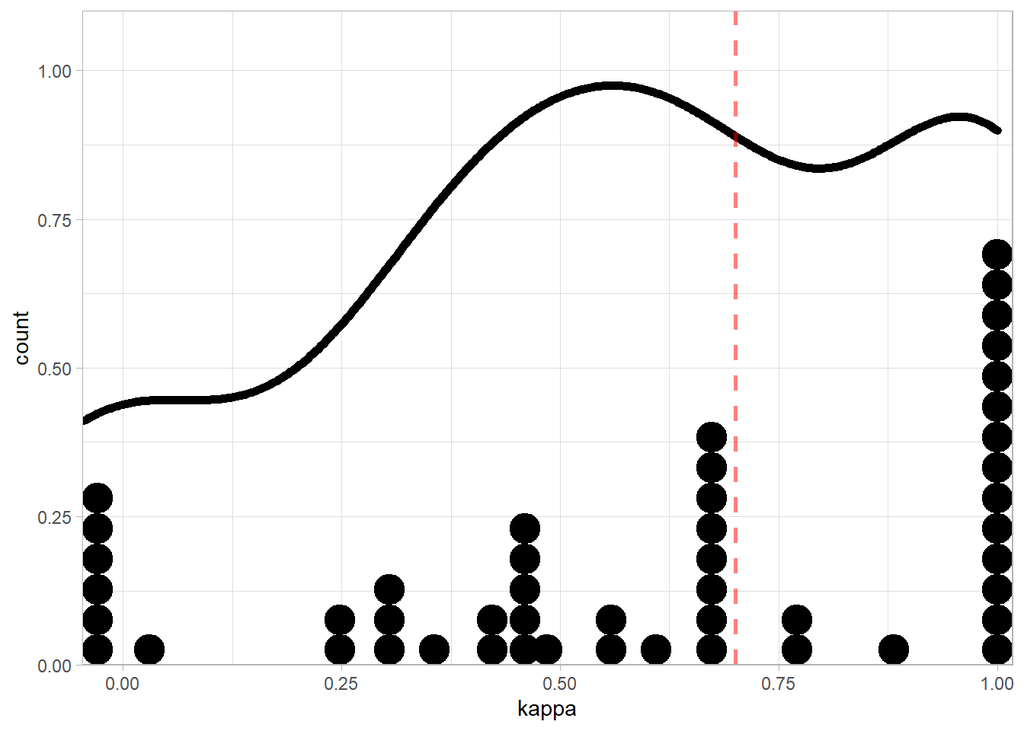

```r
# plot results kappa
ggplot(kappa_results, aes(x=kappa)) +
  geom_density(size=2) +
  geom_dotplot() +
  scale_x_continuous(expand=c(0,0)) +
  scale_y_continuous(expand=c(0,0), limits = c(0,1.1)) +
  geom_vline(xintercept = .7, color="red", alpha=.5, linetype="dashed", size=1) +
  theme_light()
```

```r
# results table
# ordered by kappa
kappa_results[order(kappa_results$kappa),] %>%
  kbl() %>%
  kable_styling()
```

|  | variable | kappa | percent |
| --- | --- | --- | --- |
| 40 | group_policy | -0.0441176 | 91.54930 |
| 7 | discipline_engtech | -0.0390244 | 91.54930 |
| 37 | group_business | -0.0215827 | 94.36620 |
| 6 | action_opentools | -0.0191388 | 95.77465 |
| 20 | geo_fin | -0.0142857 | 97.18310 |
| 23 | geo_grc | -0.0142857 | 97.18310 |
| 11 | discipline_nonspecific | 0.0303490 | 74.64789 |
| 39 | group_other | 0.2466844 | 77.46479 |
| 8 | discipline_hum | 0.2494715 | 92.95775 |
| 48 | method_other | 0.3027823 | 83.09859 |
| 3 | action_openevaluation | 0.3039216 | 94.36620 |
| 21 | geo_gbr | 0.3073171 | 94.36620 |
| 4 | action_openpolicies | 0.3564955 | 91.54930 |
| 41 | group_publisher | 0.4101765 | 77.46479 |
| 47 | method_interview | 0.4350133 | 83.09859 |
| 46 | method_documentreview | 0.4453125 | 80.28169 |
| 38 | group_librarian | 0.4552430 | 91.54930 |
| 35 | geo_usa | 0.4701493 | 94.36620 |
| 44 | group_university | 0.4701493 | 94.36620 |
| 12 | discipline_socscie | 0.4747814 | 84.50704 |
| 14 | geo_aus | 0.4855072 | 97.18310 |
| 2 | action_opendata | 0.5551378 | 85.91549 |
| 42 | group_researcher | 0.5611867 | 78.87324 |
| 10 | discipline_natscie | 0.6101961 | 90.14085 |
| 5 | action_openscience | 0.6602871 | 98.59155 |
| 27 | geo_ita | 0.6602871 | 98.59155 |
| 30 | geo_nzl | 0.6602871 | 98.59155 |
| 34 | geo_swe | 0.6602871 | 98.59155 |
| 43 | group_unisupportstaff | 0.6602871 | 98.59155 |
| 9 | discipline_med | 0.6672915 | 92.95775 |
| 29 | geo_nonspecific | 0.6789971 | 84.50704 |
| 45 | method_biblio | 0.6856862 | 87.32394 |
| 1 | action_openaccess | 0.7574722 | 88.73239 |
| 49 | method_survey | 0.7844130 | 91.54930 |
| 19 | geo_esp | 0.8814691 | 98.59155 |
| 13 | geo_are | 1.0000000 | 100.00000 |
| 15 | geo_bgd | 1.0000000 | 100.00000 |
| 16 | geo_bra | 1.0000000 | 100.00000 |
| 17 | geo_chl | 1.0000000 | 100.00000 |
| 18 | geo_chn | 1.0000000 | 100.00000 |
| 22 | geo_gha | 1.0000000 | 100.00000 |
| 24 | geo_ind | 1.0000000 | 100.00000 |
| 25 | geo_irl | 1.0000000 | 100.00000 |
| 26 | geo_irn | 1.0000000 | 100.00000 |
| 28 | geo_ken | 1.0000000 | 100.00000 |
| 31 | geo_rus | 1.0000000 | 100.00000 |
| 32 | geo_sa | 1.0000000 | 100.00000 |
| 33 | geo_svn | 1.0000000 | 100.00000 |
| 36 | geo_ven | 1.0000000 | 100.00000 |

## Agrement Results: Percentage

Since the dichotomous response categories are sometimes distributed very skewed, even a few deviations lead to very small kappa values. Percentage matches are calculated accordingly.

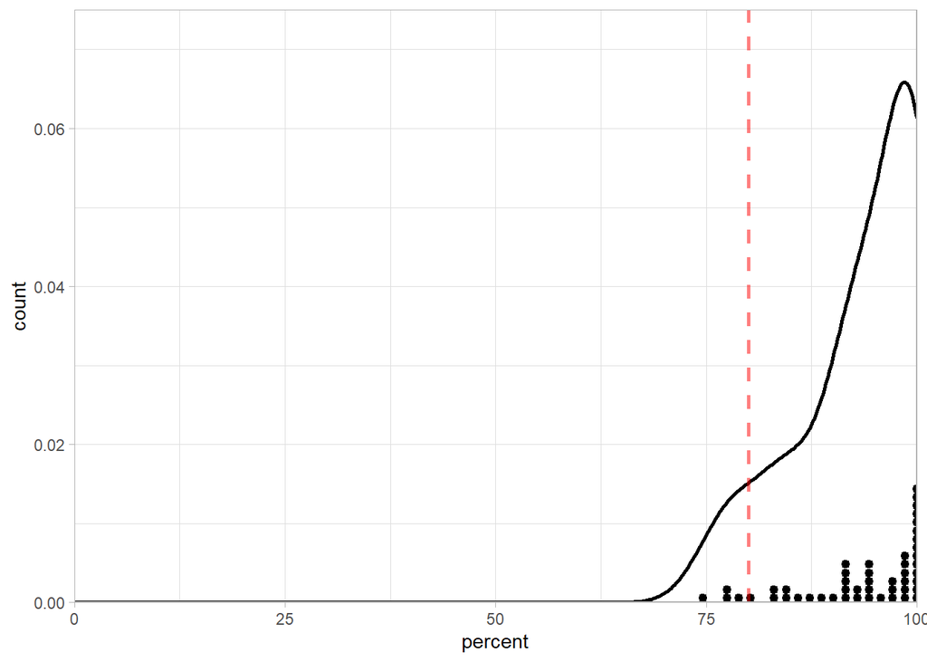

```r
# plot results percent
ggplot(kappa_results, aes(x=percent)) +
  geom_density(size=1) +
  geom_dotplot(binwidth = 1, size=2) +
  scale_x_continuous(expand=c(0,0), limits = c(0,100)) +
  scale_y_continuous(expand=c(0,0), limits = c(0,.075)) +
  geom_vline(xintercept = 80, color="red", alpha=.5, linetype="dashed", size=1) +
  theme_light()
```

```r
# results table
# ordered by percent
kappa_results[order(kappa_results$percent),] %>%
  kbl() %>%
  kable_styling()
```

|  | variable | kappa | percent |
| --- | --- | --- | --- |
| 11 | discipline_nonspecific | 0.0303490 | 74.64789 |
| 39 | group_other | 0.2466844 | 77.46479 |
| 41 | group_publisher | 0.4101765 | 77.46479 |
| 42 | group_researcher | 0.5611867 | 78.87324 |
| 46 | method_documentreview | 0.4453125 | 80.28169 |
| 47 | method_interview | 0.4350133 | 83.09859 |
| 48 | method_other | 0.3027823 | 83.09859 |
| 12 | discipline_socscie | 0.4747814 | 84.50704 |
| 29 | geo_nonspecific | 0.6789971 | 84.50704 |
| 2 | action_opendata | 0.5551378 | 85.91549 |
| 45 | method_biblio | 0.6856862 | 87.32394 |
| 1 | action_openaccess | 0.7574722 | 88.73239 |
| 10 | discipline_natscie | 0.6101961 | 90.14085 |
| 4 | action_openpolicies | 0.3564955 | 91.54930 |
| 7 | discipline_engtech | -0.0390244 | 91.54930 |
| 38 | group_librarian | 0.4552430 | 91.54930 |
| 40 | group_policy | -0.0441176 | 91.54930 |
| 49 | method_survey | 0.7844130 | 91.54930 |
| 8 | discipline_hum | 0.2494715 | 92.95775 |
| 9 | discipline_med | 0.6672915 | 92.95775 |
| 3 | action_openevaluation | 0.3039216 | 94.36620 |
| 21 | geo_gbr | 0.3073171 | 94.36620 |
| 35 | geo_usa | 0.4701493 | 94.36620 |
| 37 | group_business | -0.0215827 | 94.36620 |
| 44 | group_university | 0.4701493 | 94.36620 |
| 6 | action_opentools | -0.0191388 | 95.77465 |
| 14 | geo_aus | 0.4855072 | 97.18310 |
| 20 | geo_fin | -0.0142857 | 97.18310 |
| 23 | geo_grc | -0.0142857 | 97.18310 |
| 5 | action_openscience | 0.6602871 | 98.59155 |
| 19 | geo_esp | 0.8814691 | 98.59155 |
| 27 | geo_ita | 0.6602871 | 98.59155 |
| 30 | geo_nzl | 0.6602871 | 98.59155 |
| 34 | geo_swe | 0.6602871 | 98.59155 |
| 43 | group_unisupportstaff | 0.6602871 | 98.59155 |
| 13 | geo_are | 1.0000000 | 100.00000 |
| 15 | geo_bgd | 1.0000000 | 100.00000 |
| 16 | geo_bra | 1.0000000 | 100.00000 |
| 17 | geo_chl | 1.0000000 | 100.00000 |
| 18 | geo_chn | 1.0000000 | 100.00000 |
| 22 | geo_gha | 1.0000000 | 100.00000 |
| 24 | geo_ind | 1.0000000 | 100.00000 |
| 25 | geo_irl | 1.0000000 | 100.00000 |
| 26 | geo_irn | 1.0000000 | 100.00000 |
| 28 | geo_ken | 1.0000000 | 100.00000 |
| 31 | geo_rus | 1.0000000 | 100.00000 |
| 32 | geo_sa | 1.0000000 | 100.00000 |
| 33 | geo_svn | 1.0000000 | 100.00000 |
| 36 | geo_ven | 1.0000000 | 100.00000 |

## Agrement Results: Summary

```r
# summary of results
summary(kappa_results[2:3])
```

```
FALSE      kappa             percent
FALSE  Min.   :-0.04412   Min.   : 74.65
FALSE  1st Qu.: 0.35650   1st Qu.: 90.14
FALSE  Median : 0.66029   Median : 94.37
FALSE  Mean   : 0.58723   Mean   : 93.27
FALSE  3rd Qu.: 1.00000   3rd Qu.:100.00
FALSE  Max.   : 1.00000   Max.   :100.00
```

## Agrement Results: Summary grouped

**Kappa:**

```r
# summary of results
kappa_results %>%
  group_by(str_sub(variable, 1, 3)) %>%
  summarise(min = min(kappa),
            max = max(kappa),
            median = median(kappa)) %>%
  kbl() %>%
  kable_styling()
```

| str_sub(variable, 1, 3) | min | max | median |
| --- | --- | --- | --- |
| act | -0.0191388 | 0.7574722 | 0.4558167 |
| dis | -0.0390244 | 0.6672915 | 0.3621264 |
| geo | -0.0142857 | 1.0000000 | 1.0000000 |
| gro | -0.0441176 | 0.6602871 | 0.4327097 |
| met | 0.3027823 | 0.7844130 | 0.4453125 |

**Percent:**

```r
# summary of results
kappa_results %>%
  group_by(str_sub(variable, 1, 3)) %>%
  summarise(min = min(percent),
            max = max(percent),
            median = median(percent)) %>%
  kbl() %>%
  kable_styling()
```

| str_sub(variable, 1, 3) | min | max | median |
| --- | --- | --- | --- |
| act | 85.91549 | 98.59155 | 92.95775 |
| dis | 74.64789 | 92.95775 | 90.84507 |
| geo | 84.50704 | 100.00000 | 100.00000 |
| gro | 77.46479 | 98.59155 | 91.54930 |
| met | 80.28169 | 91.54930 | 83.09859 |